# Analisi del testo di Simpson e Griffin

Infine, il *topic* 8 (Matrimonio) presenta un andamento piuttosto peculiare: inizialmente stabile, raggiunge un picco attorno al 2000, per poi seguire un *trend* decrescente e stabilizzarsi. Anche in questo caso, si osserva una possibile connessione con i due *topic* appena menzionati.

```r
# anno fattore
meta2 <- tot_clean_out$meta
meta2$anni <- factor(meta2$anni, levels = 1989:2024)
stm_anni_fattore <- stm(documents = tot_clean_out$documents,
                vocab = tot_clean_out$vocab,
                data = meta2,
                K = 9,
                prevalence = ~ anni,
                content = ~ serie)
```

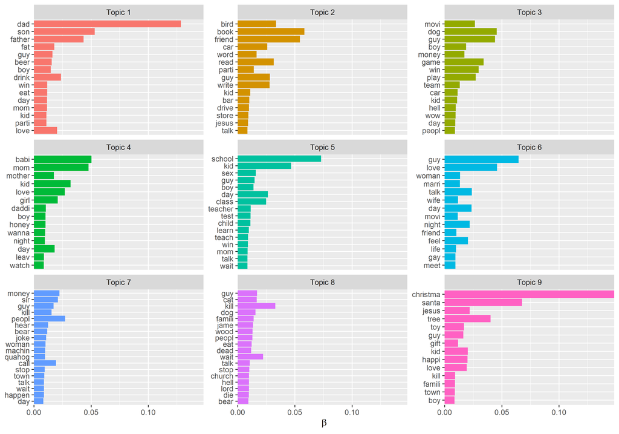

```r
# Distribuzione parola-topic
stm_anni_fattore_topics <- tidy(stm_anni_fattore, matrix = "beta")

# Crea il grafico delle prime 20 parole per topic
stm_anni_fattore_topics %>%
  group_by(topic) %>%
  slice_max(beta, n = 20) %>%
  ungroup() %>%
  mutate(topic = paste("Topic", topic)) %>%
  ggplot(aes(beta, reorder_within(term, beta, topic), fill = topic)) +
  geom_col(show.legend = FALSE) +
  facet_wrap(vars(topic), scales = "free_y") +
  scale_x_continuous(expand = c(0, 0)) +
  scale_y_reordered() +
  labs(x = expression(beta), y = NULL)
```

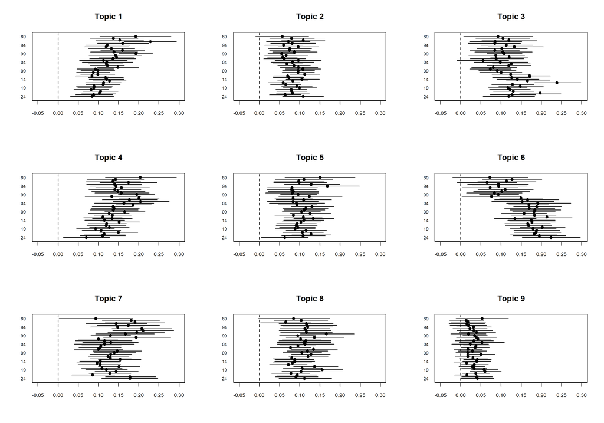

```r
effect_anni_fattore <- estimateEffect(1:9 ~ anni, stmobj = stm_anni_fattore, metadata = meta2)

par(mfrow = c(3,3))
for(i in 1:9){
  plot(effect_anni_fattore, covariate = "anni", method = "pointestimate", topics = i,
       cex = 0.75, cex.axis = 0.8, xlim = c(-0.05, 0.3), verbose.labels = F, yaxt = "n", labeltype='custom',
       custom.labels = "", main = paste0("Topic ", i))
  text(-0.08, seq(36, 1, by = -5), labels = c("89", "94", "99", "04", "09", "14", "19", "24"), xpd = T, adj=1, cex = 0.7)
}
```

```r
# anni lisciato
stm_anni_liscio <- stm(documents = tot_clean_out$documents,
                vocab = tot_clean_out$vocab,
                data = tot_clean_out$meta,
                K = 9,
                prevalence = ~ s(anni),
                content = ~ serie)
```

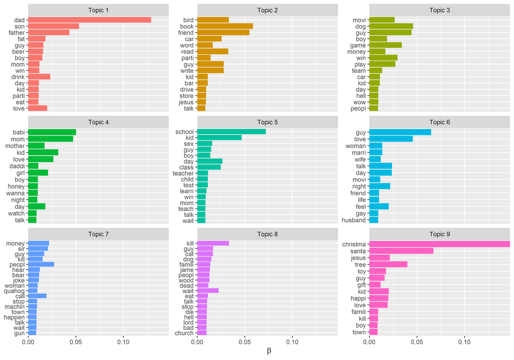

```r
# Distribuzione parola-topic ####
stm_anni_liscio_topics <- tidy(stm_anni_liscio, matrix = "beta")

# Crea il grafico delle prime 20 parole per topic
stm_anni_liscio_topics %>%
  group_by(topic) %>%
  slice_max(beta, n = 20) %>%
  ungroup() %>%
  mutate(topic = paste("Topic", topic)) %>%
  ggplot(aes(beta, reorder_within(term, beta, topic), fill = topic)) +
  geom_col(show.legend = FALSE) +
  facet_wrap(vars(topic), scales = "free_y") +
  scale_x_continuous(expand = c(0, 0)) +
  scale_y_reordered() +
  labs(x = expression(beta), y = NULL)
```

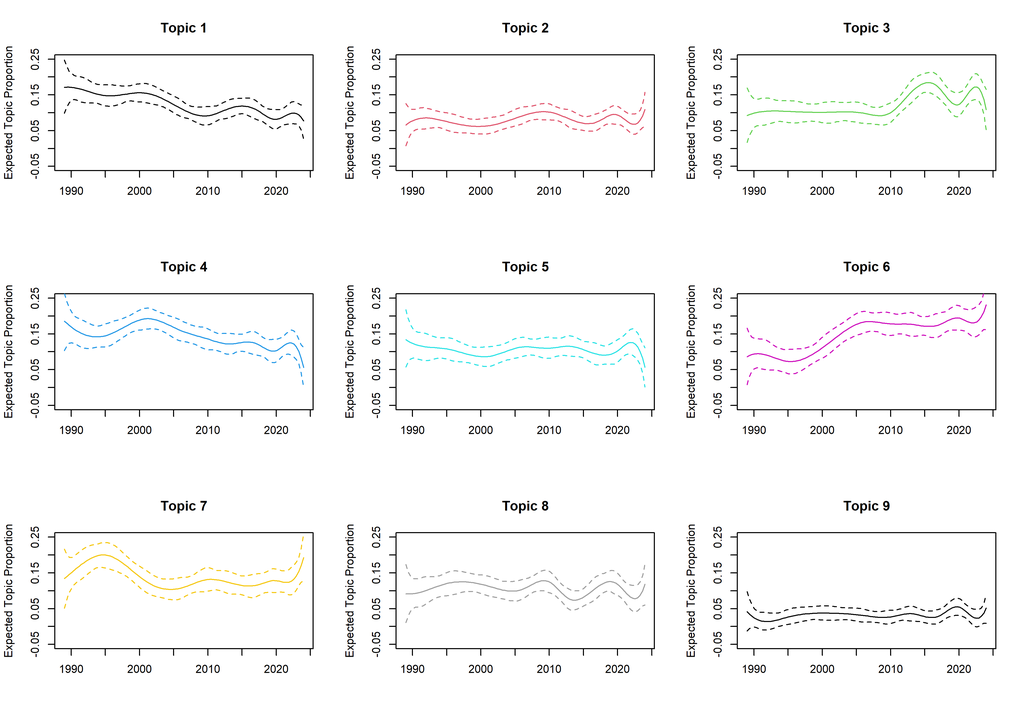

```r
effect_anni_liscio <- estimateEffect(1:9 ~ s(anni), stmobj = stm_anni_liscio, metadata = tot_clean_out$meta)

par(mfrow = c(3,3))
for(i in 1:9){
  plot(effect_anni_liscio, covariate = "anni", method = "continuous", topics = i, ylim = c(-0.05, 0.25), linecol = i, printlegend = F, main=paste0("Topic ", i))
}
```

Infine, si stima il modello che considera come covariate le varie presenze/assenze dei produttori nelle serie. Si noti come la correlazione con la variabile `anni` non è perfetta, a causa della presenza discontinua o della collaborazione tra produttori.

```r
# Produttori
f_prod <- paste0("~ - 1 + ", paste0(colnames(produttori), collapse=" + "))
stm_produttori <- stm(documents = tot_clean_out$documents,
                        vocab = tot_clean_out$vocab,
                        data = tot_clean_out$meta,
                        K = 9,
                        prevalence = as.formula(f_prod),
                        content = ~ serie)
```

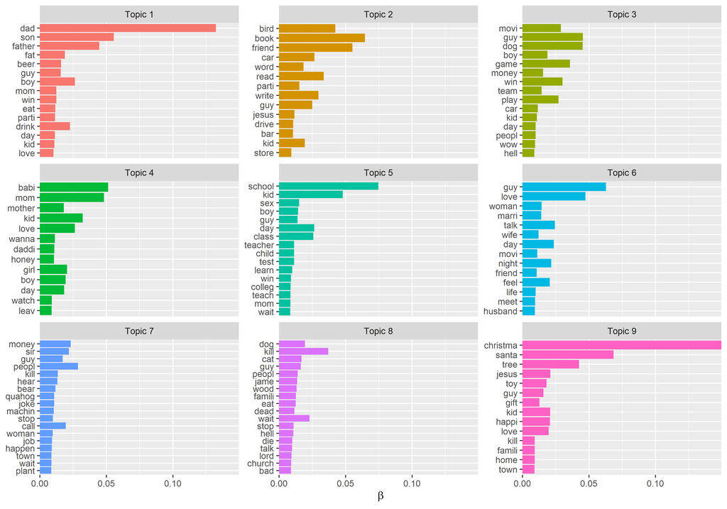

```r
# Riorganizza la matrice beta (distribuzione parola-topic)
stm_produttori_topics <- tidy(stm_produttori, matrix = "beta")

# Crea il grafico delle prime 20 parole per topic
stm_produttori_topics %>%
  group_by(topic) %>%
  slice_max(beta, n = 20) %>%
  ungroup() %>%
  mutate(topic = paste("Topic", topic)) %>%
  ggplot(aes(beta, reorder_within(term, beta, topic), fill = topic)) +
  geom_col(show.legend = FALSE) +
  facet_wrap(vars(topic), scales = "free_y") +
  scale_x_continuous(expand = c(0, 0)) +
  scale_y_reordered() +
  labs(x = expression(beta), y = NULL)
```

A differenza delle altre covariate, i produttori non mostrano effetti particolarmente forti, fatte alcune eccezioni. Come osservato già in precedenza, alcuni *topic* non sembrano influenzati da fattori esterni: il *topic* 9 è l’esempio più evidente. Volgendo l’attenzione ai singoli produttori, si distinguono in particolare Palladino (per *I Griffin*) e Reiss (per *I Simpson*). L’effetto stimato di questi due produttori si distingue infatti in modo abbastanza costante al variare del *topic* considerato. È però bene precisare che il numero di episodi a cui ogni produttore ha contribuito è molto variabile, ed in alcuni casi anche ridotto. Questo può rendere più instabili le stime, e le conclusioni meno affidabili, come si nota dagli *standard error* talvolta elevati ed i conseguenti intervalli di confidenza ampi.

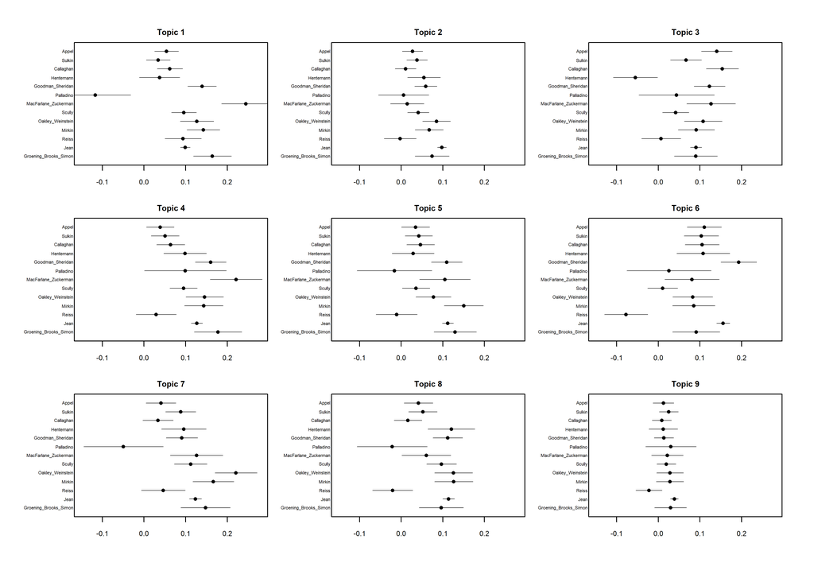

```r
effect_produttori <- estimateEffect(as.formula(paste0("1:9 ", f_prod)), stmobj = stm_produttori, metadata = tot_clean_out$meta)

par(mfrow = c(3,3),
    mar = c(3, 5, 2, 1),
    oma = c(2, 2, 2, 2),
    cex.main = 0.9,
    cex.lab = 0.8)

for(i in 1:9){
  # Plot vuoto per impostare gli assi
  plot(1, type = "n", xlim = c(-0.15, 0.28), ylim = c(0.5, 13.5),
       xaxt = "n", yaxt = "n", xlab = "Effetto stimato", ylab = "", main = paste("Topic", i))

  axis(1, cex.axis = 0.8)

  for(j in seq_along(colnames(produttori))){
    cov_name <- colnames(produttori)[j]
    eff <- summary(effect_produttori)$tables[[i]]

    # Trova la riga corrispondente alla covariata j
    if (cov_name %in% rownames(eff)) {
      est <- eff[cov_name, 1]
      se <- eff[cov_name, 2]

      y_pos <- j

      # Punto + errore standard
      points(est, y_pos, pch = 16, cex = 0.9)
      segments(est - 1.96 * se, y_pos, est + 1.96 * se, y_pos, lwd =  0.7)
    }
  }

  text(-0.17, seq(1, 13), labels = colnames(produttori), xpd = T, adj=1, cex = 0.5)
}
```

Si ricorda che è difficile trarre conclusioni in senso causale in analisi statistiche di questo tipo, soprattutto perché la presenza di un *topic* può essere causata da una varietà di ragioni concomitanti, esogene o endogene alla produzione della serie. Queste difficoltà sono intrinseche alle analisi di tipo sociologico, dove il controllo delle variabili è spesso difficile, se non impossibile. Le evoluzioni delle serie analizzate potrebbero essere dovute ad uno sviluppo fisiologico delle stesse, o a preferenze espresse dal pubblico, ma allo stesso tempo un produttore o il contesto socio-culturale differenti potrebbero aver esercitato un’influenza analoga.

## *Sentiment Analisys*

Si prova ora ad analizzare il *sentiment* delle due serie in oggetto. Per effettuare la *Sentiment Analisys* si utilizza il metodo *lexicon-based*, che assegna ad ogni parola un punteggio da -5 (parola molto negativa) a +5 (parola molto positiva).

```r
# tokenizza il testo in singole parole
token_simpson <- simpson_clean %>%
  unnest_tokens(word, testo)
token_griffin <- griffin_clean %>%
  unnest_tokens(word, testo)

token_simpson_2 <- simpson_clean_2 %>%
  unnest_tokens(word, testo)
token_griffin_2 <- griffin_clean_2 %>%
  unnest_tokens(word, testo)

# Carica il dataset dei dizionari di sentiment disponibili
data("sentiments")

# Estrae il dizionario AFINN
lexicon <- get_sentiments("afinn") # Scala da -5 (negativo) a +5 (positivo)
```

Si calcolano dunque il *sentiment* medio per episodio, e poi per stagione.

```r
# Calcola il sentiment medio per episodio
sentiment_per_episode_s <- token_simpson %>%
  left_join(lexicon, by = "word") %>%  # Unisce le parole con il loro punteggio di sentiment
  group_by(stagione, episodio) %>%     # Raggruppa per stagione ed episodio
  summarise(
    sentiment = mean(value, na.rm = TRUE),  # Calcola il sentiment medio, ignorando i NA
    n_words = n()                           # Conta il numero di parole totali
  ) %>%
  filter(n_words > 10)  # Mantiene solo episodi con almeno 10 parole presenti nel dizionario
# Calcola il sentiment medio per stagione dei Simpson
sentiment_per_seasion_medio_s <- sentiment_per_episode_s %>%
  group_by(stagione) %>%                   # Raggruppa per stagione
  summarise(sentiment = mean(sentiment)) %>%  # Calcola la media dei sentiment per stagione
  mutate(show = "simpson")                # Aggiunge una colonna che indica la serie
```

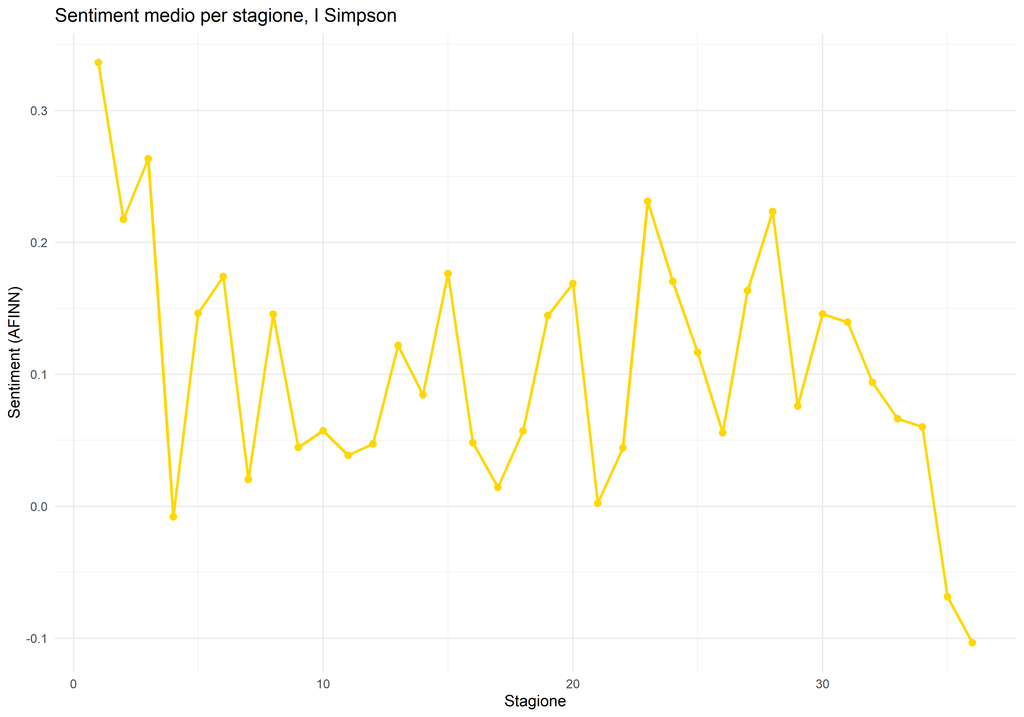

```r
# Grafico: sentiment medio per stagione dei Simpson
sentiment_per_seasion_medio_s %>%
  ggplot(aes(x = stagione, y = sentiment)) +  # Asse x = stagione, y = sentiment medio
  geom_line(color = "#FFD700", linewidth = 1) +
  geom_point(size = 2, color = "#FFD700") +
  theme_minimal() +
  labs(title = "Sentiment medio per stagione, I Simpson", x = "Stagione", y = "Sentiment (AFINN)")
```

Si ripete l’analisi del *sentiment* con lo stesso dizionario per *I Griffin*.

```r
# Calcola il sentiment medio per episodio dei Griffin
sentiment_per_episode_g <- token_griffin %>%
  left_join(lexicon, by = "word") %>%  # Join con dizionario AFINN
  group_by(stagione, episodio) %>%     # Raggruppa per stagione ed episodio
  summarise(
    sentiment = mean(value, na.rm = TRUE),  # Media del sentiment
    n_words = n()                           # Numero di parole nel dizionario per episodio
  ) %>%
  filter(n_words > 10)  # Esclude episodi con meno di 10 parole presenti nel dizionario
# Calcola il sentiment medio per stagione dei Griffin
sentiment_per_seasion_medio_g <- sentiment_per_episode_g %>%
  group_by(stagione) %>%                    # Raggruppa per stagione
  summarise(sentiment = mean(sentiment)) %>% # Calcola la media
  mutate(show = "griffin")                 # Aggiunge colonna con nome serie
```

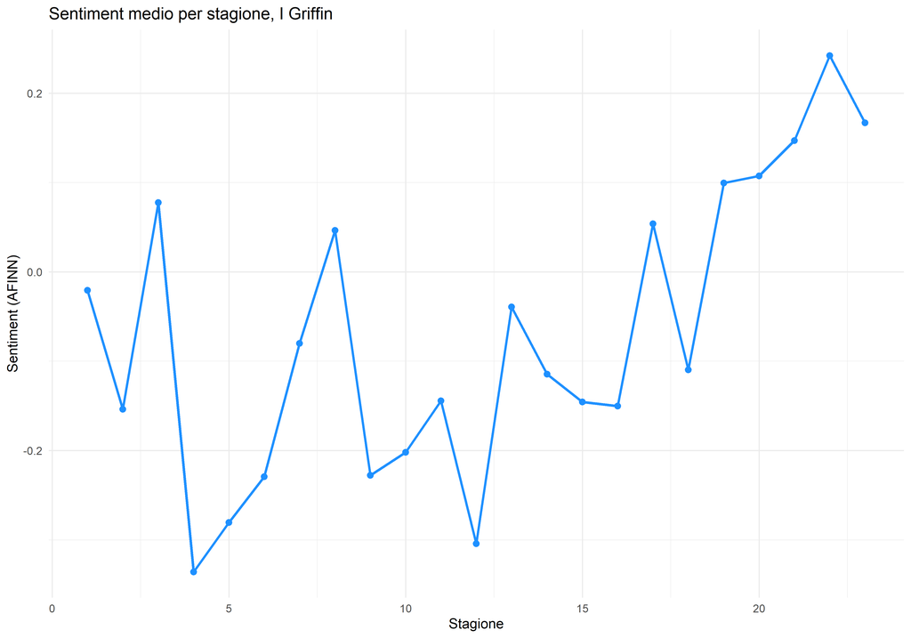

```r
# Grafico: sentiment medio per stagione dei Griffin
sentiment_per_seasion_medio_g %>%
  ggplot(aes(x = stagione, y = sentiment)) +
  geom_line(color = "#1E90FF", linewidth = 1) +
  geom_point(size = 2, color = "#1E90FF") +
  theme_minimal() +
  labs(title = "Sentiment medio per stagione, I Griffin", x = "Stagione", y = "Sentiment (AFINN)")
```

Il grafico combinato evidenzia meglio il carattere mediamente opposto delle due serie in termini di *sentiment*, anche se le ultime stagioni sembrano sollevare un’inversione.

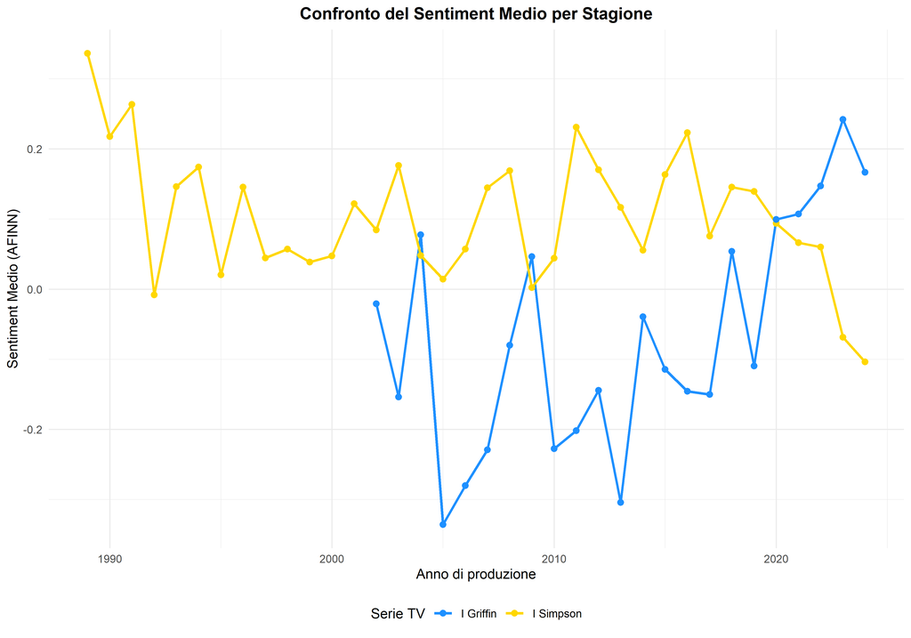

```r
# Unisce i dataset dei sentiment medi per stagione
combined_results <- bind_rows(sentiment_per_seasion_medio_s %>% mutate(stagione = stagione + 1988),
                              sentiment_per_seasion_medio_g %>% mutate(stagione = stagione + 13 + 1988) )

ggplot(combined_results, aes(
  x = stagione,
  y = sentiment,
  color = show,
  group = show
)) +
  geom_line(linewidth = 1) +
  geom_point(size = 2) +
  scale_color_manual(
    values = c("simpson" = "#FFD700", "griffin" = "#1E90FF"),  # Oro e blu
    labels = c("I Griffin", "I Simpson")  # Etichette leggibili
  ) +
  labs(
    title = "Confronto del Sentiment Medio per Stagione",
    x = "Anno di produzione",
    y = "Sentiment Medio (AFINN)",
    color = "Serie TV"
  ) +
  theme_minimal() +
  theme(
    plot.title = element_text(hjust = 0.5, face = "bold"),
    legend.position = "bottom"
  )
```

La *wordcloud* del *sentiment* mostra le parole più frequentri tra quelle con il *sentiment* più alto e più basso. La dimensione della parola riflette la sua frequenza, mentre l’intensità del colore è data dal punteggio assegnato (in verde le parole positive, in rosso le negative).

I risultati non sono sorprendenti, e portano a supporre che le maggiori volgarità ed oscenità de *I Griffin* siano legate al *sentiment* decisamente inferiore, rispetto a *I Simpson*, notoriamente più *family-friendly*.

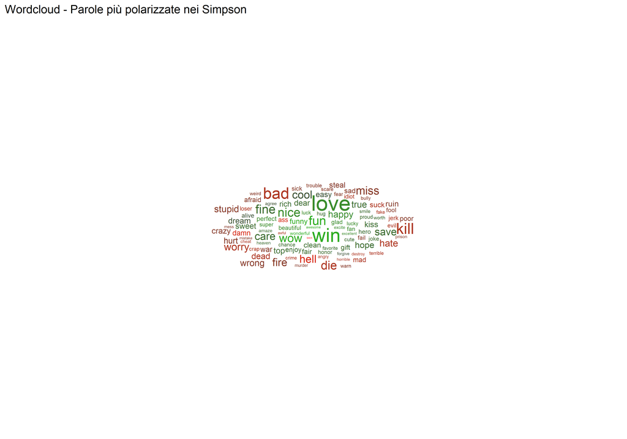

```r
# Preparazione dati Simpson
polar_words_s <- token_simpson %>%
  left_join(get_sentiments("afinn"), by = "word") %>%
  filter(!is.na(value)) %>%
  group_by(word) %>%
  summarise(
    freq=n(),
    avg_sentiment = mean(value),
    .groups = "drop"
  )

# Ordina per sentiment medio (più positive)
positive_words_s <- polar_words_s %>%
  arrange(desc(avg_sentiment)) %>%  # Dal più positivo
  head(50)

# Ordina per sentiment medio (più negative)
negative_words_s <- polar_words_s %>%
  arrange(avg_sentiment) %>%  # Dal più negativo
  head(50)

# Unisce le parole più positive e più negative
combined_words_s <- bind_rows(positive_words_s, negative_words_s)

# Grafico
ggplot(combined_words_s, aes(label = word, size = freq, color = avg_sentiment)) +
  geom_text_wordcloud_area() +
  scale_color_gradient2(
    low = "red",
    mid = "grey20",
    high = "green3",
    midpoint = 0,
    name = "Sentiment"
  ) +
  scale_size_area(max_size = 15) +
  labs(title = "Wordcloud - Parole più polarizzate nei Simpson") +
  theme_minimal()
```

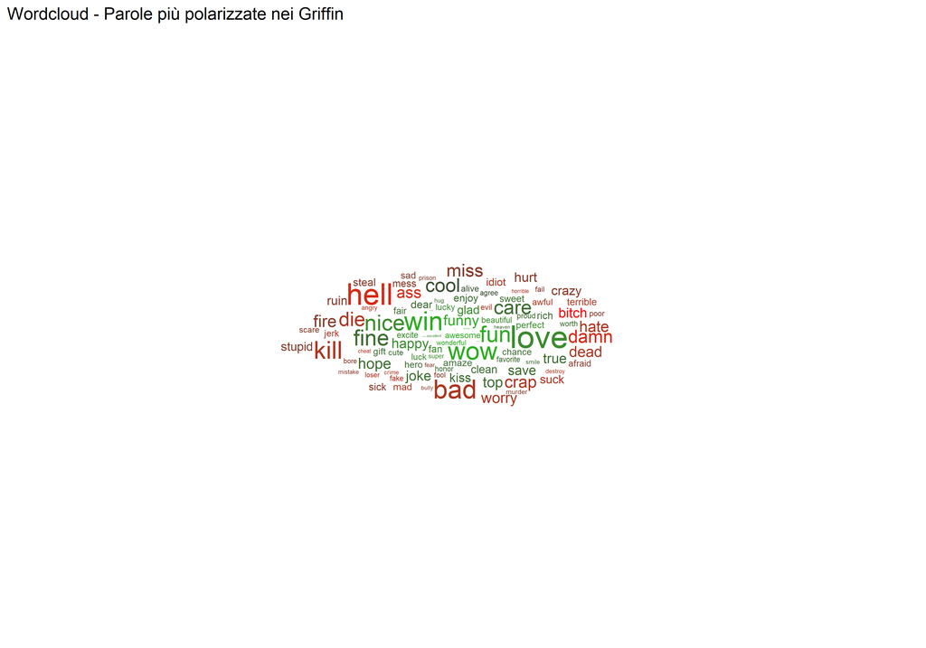

```r
# Preparazione dati
polar_words_g <- token_griffin %>%
  left_join(get_sentiments("afinn"), by = "word") %>%
  filter(!is.na(value)) %>%
  group_by(word) %>%
  summarise(
    freq=n(),
    avg_sentiment = mean(value),
    .groups = "drop")

# Ordina per sentiment medio (più positive)
positive_words_g <- polar_words_g %>%
  arrange(desc(avg_sentiment)) %>%  # Dal più positivo
  head(50)

# Ordina per sentiment medio (più negative)
negative_words_g <- polar_words_g %>%
  arrange(avg_sentiment) %>%  # Dal più negativo
  head(50)

# Unisce le parole più positive e più negative
combined_words_g <- bind_rows(positive_words_g, negative_words_g)

ggplot(combined_words_g, aes(label = word, size = freq, color = avg_sentiment)) +
  geom_text_wordcloud_area() +
  scale_color_gradient2(
    low = "red",
    mid = "grey20",
    high = "green3",
    midpoint = 0,
    name = "Sentiment"
  ) +
  scale_size_area(max_size = 15) +
  labs(title = "Wordcloud - Parole più polarizzate nei Griffin") +
  theme_minimal()
```

### Sentiment dei *topic*

Si è ritenuto d’interesse analizzare il *sentiment* medio per ciascun *topic*, sia per le serie prese singolarmente, sia nel caso congiunto. Di seguito, si prelevano dagli oggetti di *topic modeling* le appartenenze dei vari episodi, per poi fare un *join* con i dati di IMDb.

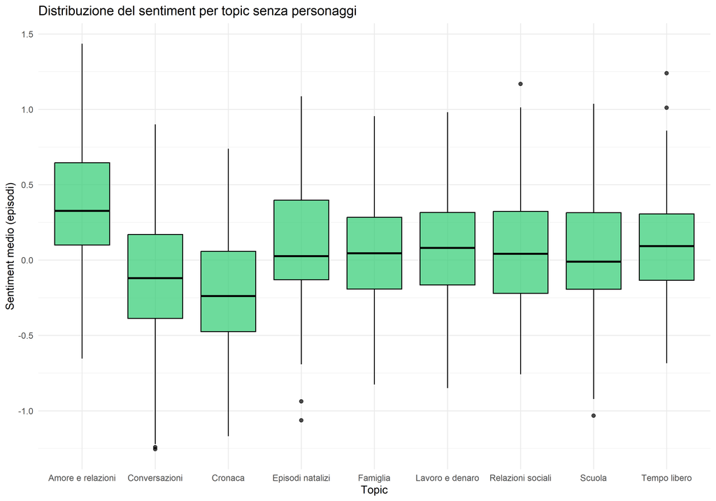

```r
# sentiment medio dei topic
# sentiment_lda_imdb_tot %>%
#   group_by(titolo_topic) %>%
#   summarise(sentiment = mean(sentiment))
#
# sentiment_lda_imdb_tot_2 %>%
#   group_by(titolo_topic) %>%
#   summarise(sentiment = mean(sentiment))

# boxplot topic
ggplot(sentiment_lda_imdb_tot, aes(x = factor(titolo_topic), y = sentiment)) +
  geom_boxplot(fill = "#2ECC71", color = "black", alpha = 0.7) +
  labs(
    title = "Distribuzione del sentiment per topic senza personaggi",
    x = "Topic",
    y = "Sentiment medio (episodi)"
  ) +
  theme_minimal()
```

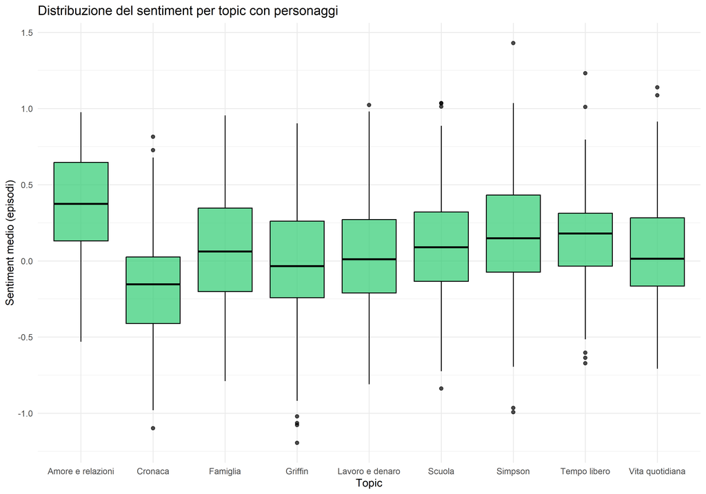

```r
ggplot(sentiment_lda_imdb_tot_2, aes(x = factor(titolo_topic), y = sentiment)) +
  geom_boxplot(fill = "#2ECC71", color = "black", alpha = 0.7) +
  labs(
    title = "Distribuzione del sentiment per topic con personaggi",
    x = "Topic",
    y = "Sentiment medio (episodi)"
  ) +
  theme_minimal()
```

Di seguito, si manipolano ulteriormente i dati per un grafico trivariato.

```r
# Vettore degli anni in cui sono usciti gli episodi
anno = c(1989:2024, 1999, 1999, 2001, 2005:2024)

# Numero di episodi per stagione per ciascuna serie, calcolato con rle()
epi_per_stag = c(
  rle(simpson_clean$stagione)$lengths,
  rle(griffin_clean$stagione)$lengths
)

# Costruisce un dataframe con informazioni su anno, serie, stagione e episodio
anni <- data.frame(
  anno = rep(anno, epi_per_stag),
  serie = c(rep("S", nrow(simpson_clean)),
            rep("G", nrow(griffin_clean))),
  stagione = tot_clean$stagione,
  episodio = tot_clean$episodio)

# Crea un identificativo univoco per ogni episodio
anni$doc_id <- paste0(
  anni$serie,
  "_S", ifelse(anni$stagione < 10, paste0("0", anni$stagione), anni$stagione),
  "_E", ifelse(anni$episodio < 10, paste0("0", anni$episodio), anni$episodio))

# Unisce il dataframe "anni" al dataframe dei risultati di sentiment+topic, usando doc_id
sentiment_lda_imdb_tot <- sentiment_lda_imdb_tot %>% inner_join(anni, by = c("doc_id" = "doc_id"))

sentiment_lda_imdb_tot_2 <- sentiment_lda_imdb_tot_2 %>% inner_join(anni, by = c("doc_id" = "doc_id"))
```